# TP5: Hierarchical Model I

Author

Lionel Hertzog

Published

September 11, 2026

```r
library(lme4)
library(tidyverse)
library(ggeffects)
```

## 1 Objectives

This practical aims at discovering hierarchical models, we will rely on the `lme4` package to fit the models. The data used are flora species richness at NFI plots situated in different sylvoecoregions.

Remember the standard formula for a simple hierarchical model:

$$\mu_{ij} = \beta_0 + \gamma_j + \beta_1 * X_i + ...$$
$$\gamma_j \sim N(0, \sigma_{hier})$$

With $j$ a grouping index, in our case this will be the sylvoécoregions.

## 2 Read the data

Load the `dat_tp5.csv` into R. Perform quick exploration of the dataset.

```r
here::i_am("practicals/tp5.qmd")
dat <- read.csv("../data/dat_tp5.csv")

head(dat)
```

```
      idp rich ser_86              pro_psg elev tcar esspre_fr
1 1005709   19    G11     privé - sans psg  319    1         R
2 1001933   50    C52     privé - sans psg  763    4         F
3 1001580   12    B33     privé - sans psg  206   10         F
4 1031119   26    I11     privé - sans psg  515   10         F
5 1007941   37    C20 publics - domaniales  465    8         F
6 1008363   35    F12 publics - domaniales  122    2         F
```

## 3 Fit a first non-hierarchical model

First fit a non-hierarchical model with (g)lm with the following formula:

```
rich ~ ser_86 + elev + tcar + pro_psg + esspre_fr
```

```r
m <- lm(rich ~ ser_86 + elev + tcar + pro_psg + esspre_fr, data = dat)
summary(m)
```

```
Call:
lm(formula = rich ~ ser_86 + elev + tcar + pro_psg + esspre_fr,
    data = dat)

Residuals:
    Min      1Q  Median      3Q     Max
-42.801  -6.142  -1.058   4.939  60.724

Coefficients:
                              Estimate Std. Error t value Pr(>|t|)
(Intercept)                 18.4533022  1.2737675  14.487  < 2e-16 ***
ser_86A12                   -2.3445826  2.0454000  -1.146 0.251732
ser_86A13                   -3.4646440  1.7491624  -1.981 0.047669 *
ser_86A21                   -3.6318822  2.1065365  -1.724 0.084745 .
ser_86A22                   -2.3683128  1.8416937  -1.286 0.198516
ser_86A30                   -0.4336830  2.1059333  -0.206 0.836850
ser_86B10                   -1.2492304  1.5949813  -0.783 0.433528
ser_86B21                    7.0405194  3.0430429   2.314 0.020723 *
ser_86B22                    1.4180630  2.4948090   0.568 0.569783
ser_86B23                   10.3524261  2.5054709   4.132 3.65e-05 ***
ser_86B31                   -0.1789410  2.3690672  -0.076 0.939794
ser_86B32                   -3.9057579  1.6604018  -2.352 0.018692 *
ser_86B33                   -2.7865457  1.7519218  -1.591 0.111764
ser_86B41                    1.4652020  1.4415674   1.016 0.309485
ser_86B42                    5.8634408  1.6472581   3.560 0.000375 ***
ser_86B43                    8.6175545  2.2065158   3.906 9.51e-05 ***
ser_86B44                   -0.3635342  2.8604678  -0.127 0.898874
ser_86B51                    8.6723902  1.6738686   5.181 2.28e-07 ***
ser_86B52                    1.7543603  1.8545255   0.946 0.344195
ser_86B53                    3.7308977  1.8074343   2.064 0.039045 *
ser_86B61                   -3.4669682  1.6813100  -2.062 0.039248 *
ser_86B62                    0.4527383  1.6184583   0.280 0.779692
ser_86B70                    0.6305680  1.4144076   0.446 0.655746
ser_86B81                   -1.6720468  2.2344724  -0.748 0.454313
ser_86B82                    2.5593273  1.7985754   1.423 0.154799
ser_86B91                    2.1218718  1.6634226   1.276 0.202148
ser_86B92                    5.8261736  1.8269504   3.189 0.001435 **
ser_86C11                    2.9445940  2.3111225   1.274 0.202682
ser_86C12                    5.1047258  2.3738765   2.150 0.031568 *
ser_86C20                   11.0981656  1.2660559   8.766  < 2e-16 ***
```

[output cut: 54 more lines]

```
ser_86K12                   12.3516572  2.5574558   4.830 1.40e-06 ***
ser_86K13                   13.2727924  2.5113207   5.285 1.30e-07 ***
elev                        -0.0016320  0.0008509  -1.918 0.055151 .
tcar                        -0.1079649  0.0531907  -2.030 0.042427 *
pro_psgprivé - sans psg      1.4717234  0.4065195   3.620 0.000297 ***
pro_psgpublics - domaniales -0.2202073  0.5660317  -0.389 0.697264
pro_psgpublis - communales  -0.0267390  0.5205712  -0.051 0.959037
esspre_frR                   0.6179331  0.3589610   1.721 0.085225 .
---
Signif. codes:  0 '***' 0.001 '**' 0.01 '*' 0.05 '.' 0.1 ' ' 1

Residual standard error: 10.14 on 5581 degrees of freedom
  (6 observations deleted due to missingness)
Multiple R-squared:  0.3545,    Adjusted R-squared:  0.344
F-statistic: 33.69 on 91 and 5581 DF,  p-value: < 2.2e-16
```

We are estimating one coefficient separately for each regions, this is inefficient, especially for regions with low number of plots.

## 4 Fit a hierarchical model

### 4.1 Fit

Using *lme4* fit the same model as before but putting the sylvoécoregions code as hierarchical term, in other words allowing for average richness to vary per regions. The main functions to fit these models are `lmer` for normal distribution and `glmer` for other distributions.

**TipHint**

A variable intercept hierarchical term, which is what we want here, can be coded in the model formula as:

```
lmer(y ~ ... + (1 | ser_86), ...)
```

The `(1 | ser_86)` synthax imply that the intercept (the `1`) vary per ser_86 level.

### 4.2 Explore

```r
summary(m)
```

```
Linear mixed model fit by REML ['lmerMod']
Formula: rich ~ elev + pro_psg + esspre_fr + tcar + (1 | ser_86)
   Data: dat

REML criterion at convergence: 42670.6

Scaled residuals:
    Min      1Q  Median      3Q     Max
-3.9700 -0.6064 -0.1099  0.4914  6.0166

Random effects:
 Groups   Name        Variance Std.Dev.
 ser_86   (Intercept)  50.76    7.124
 Residual             102.86   10.142
Number of obs: 5673, groups:  ser_86, 86

Fixed effects:
                              Estimate Std. Error t value
(Intercept)                 23.3810571  1.0018053  23.339
elev                         0.0004615  0.0007904   0.584
pro_psgprivé - sans psg      1.6883513  0.4047050   4.172
pro_psgpublics - domaniales -0.2023346  0.5653308  -0.358
pro_psgpublis - communales   0.1200139  0.5193798   0.231
esspre_frR                   0.5779215  0.3581614   1.614
tcar                        -0.1036297  0.0530389  -1.954
```

```
Correlation of Fixed Effects:
```

```
            (Intr) elev   pr_-sp pr_p-d pr_p-c essp_R
elev        -0.336
pr_psgpr-sp -0.336  0.061
pr_psgpbl-d -0.188 -0.042  0.482
pr_psgpbl-c -0.206 -0.079  0.587  0.438
esspre_frR  -0.052 -0.155  0.094 -0.011  0.025
tcar        -0.404  0.039  0.000  0.004 -0.015 -0.024
```

The residual standard deviaiton is estimated at 10 and the standard deviaion of the region varying intercept is estimated at 7, so close to the unexplained variation.

```r
fixef(m)
```

```
                (Intercept)                        elev
              23.3810570715                0.0004614828
    pro_psgprivé - sans psg pro_psgpublics - domaniales
               1.6883512860               -0.2023346406
 pro_psgpublis - communales                  esspre_frR
               0.1200138624                0.5779214506
                       tcar
              -0.1036296633
```

```r
ranef(m)
```

```
$ser_86
     (Intercept)
A11  -5.29136779
A12  -7.23269293
A13  -8.61906045
A21  -8.39410326
A22  -7.27445261
A30  -5.39679585
B10  -6.39505326
B21   1.65838574
B22  -3.52654974
B23   4.55735098
B31  -5.12549683
B32  -8.96117979
B33  -7.95180348
B41  -3.78289065
B42   0.44568612
B43   2.98070079
B44  -5.06674629
B51   3.12310301
B52  -3.55948037
B53  -1.76004390
B61  -8.44034975
B62  -4.73212209
B70  -4.58665006
B81  -6.48605542
B82  -2.66599065
B91  -3.25081577
B92   0.13655814
C11  -2.50177927
C12  -0.36239070
C20   5.29144726
C30  -4.12396470
C41  -1.58970558
C42  -0.80113049
C51  -2.31345549
C52   3.91153131
D11  -5.84013349
D12  -7.44913058
E10  10.39088819
```

[output cut: 35 more lines]

```
I13  -4.79849171
I21   4.69638761
I22   6.42429115
J10   3.23906284
J21   4.09150975
J22   1.28184196
J23   1.24218246
J24  -2.59113545
J30  -3.48431945
J40  -1.09036315
K11   1.04016853
K12   4.40114936
K13   6.51830957

with conditional variances for "ser_86"
```

The non-varying coefficients (fixef) show relatively low effects of the selected variables, richness tend to be higher in private forests without management plans, in coniferous forests and decline with tree cover.

The varying intercept show relatively large variations between the regions.

## 5 Interprete the covariables effects

### 5.1

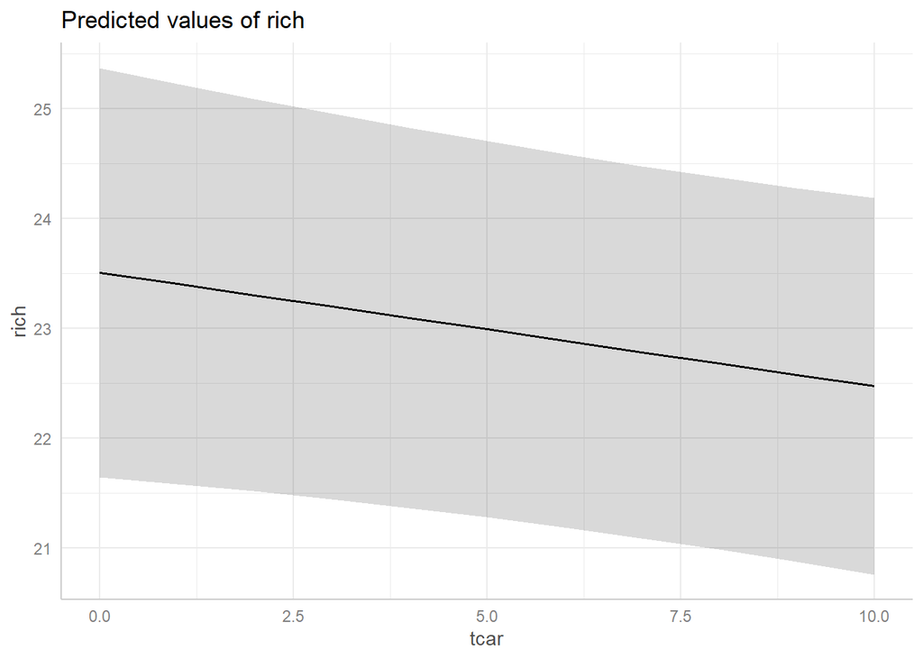

```r
predict_response(m, terms = "tcar") %>%
  plot()
```

### 5.2

```r
library(rsq)
rsq(m)
```

```
$model
[1] 0.3438067

$fixed
[1] 0.02037121

$random
[1] 0.3234354
```

## 6 Interprete the varying intercept

### 6.1

```r
ser_var <- ranef(m)
ser_df <- data.frame(ser_86 = rownames(ser_var$ser_86),
                     ser_eff = ser_var$ser_86[,1],
                     ser_var = attr(ser_var$ser_86, "postVar")[,,1:86])
head(ser_df)
```

```
  ser_86   ser_eff  ser_var
1    A11 -5.291368 1.285263
2    A12 -7.232693 2.704827
3    A13 -8.619060 1.658244
4    A21 -8.394103 2.936493
5    A22 -7.274453 1.976975
6    A30 -5.396796 2.936493
```

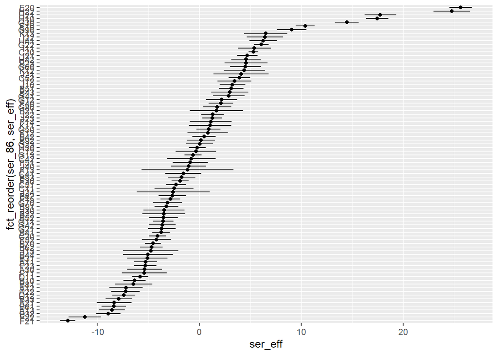

```r
library(tidyverse)
ggplot(ser_df, aes(x = fct_reorder(ser_86, ser_eff),
                   y = ser_eff,
                   ymin = ser_eff - sqrt(ser_var),
                   ymax = ser_eff + sqrt(ser_var))) +
  geom_point() +
  geom_linerange() +
  coord_flip()
```

The plotted values are the deviation from the intercept, estimated at 23 species. Negative values mean regions with lower than average species richness.

### 6.2 Bonus

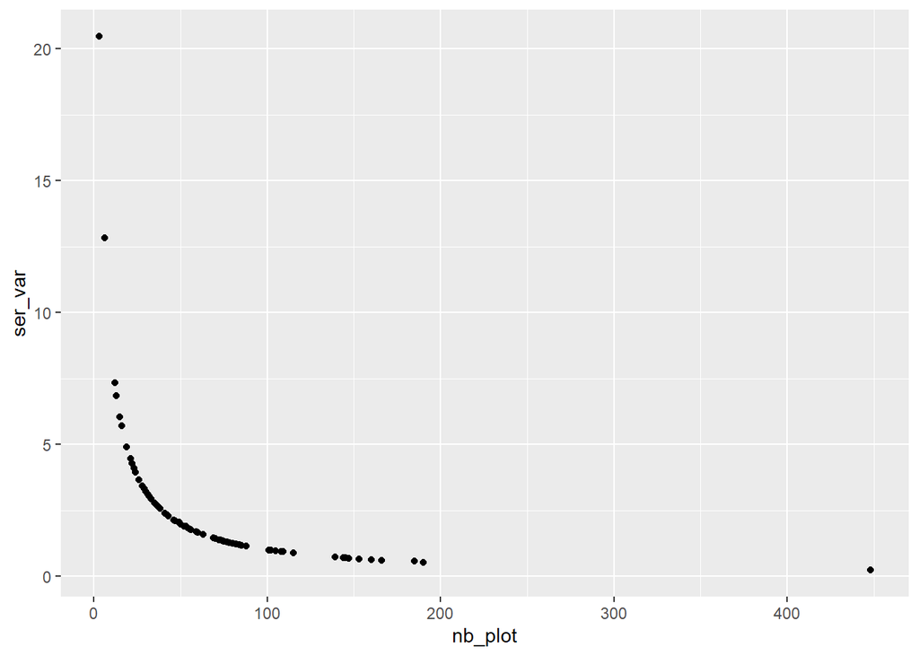

```r
ser_df$nb_plot <- count(dat, ser_86)$n
ggplot(ser_df, aes(x = nb_plot, y = ser_var)) +
  geom_point()
```

### 6.3

The output of the `ranef` function are the deviation to the population-level intercept, negative values meaning lower richness values for the given region compared to the average. To get the predicted average richness level per region, the function `ggeffects::predict_response(..., type = "random")` can be used.

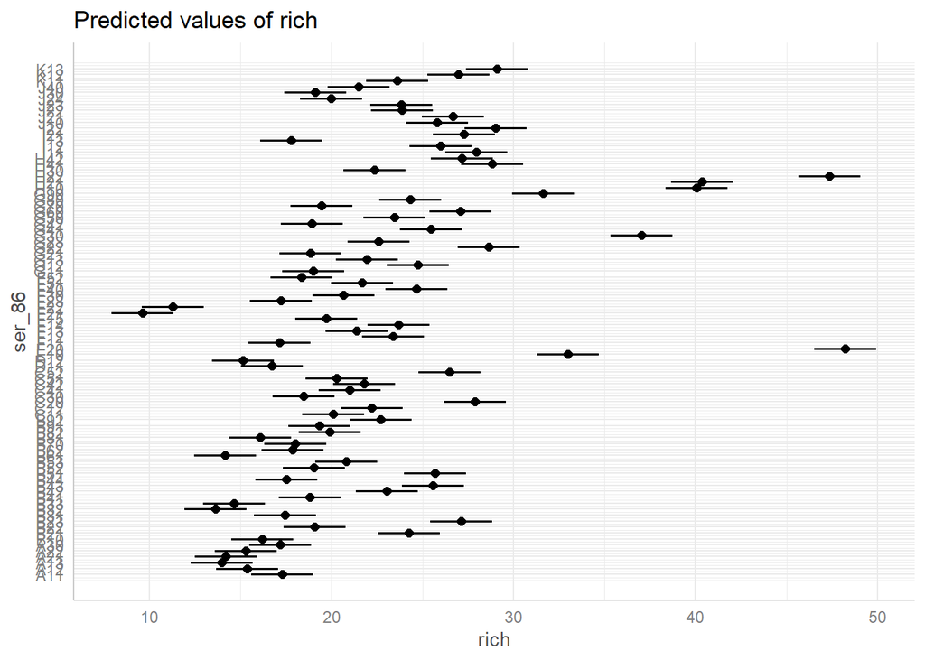

```r
predict_response(m, terms = "ser_86", type = "random") %>%
  plot() +
  coord_flip()
```

## 7 Bonus: make a map

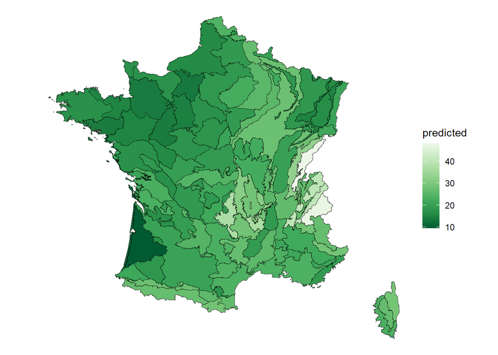

```r
library(sf)
library(tidyverse)
ser_shape <- st_read("../data/ser_27572.gpkg")
ser_pred <- as.data.frame(ggeffects::predict_response(m, terms = "ser_86", type = "random"))
ser_plot <- inner_join(ser_pred, ser_shape, by = c("x" = "codeser"))

ggplot(ser_plot, aes(fill = predicted, geometry = geom)) +
  geom_sf() +
  scale_fill_distiller(palette = "Greens", direction = -1) +
  theme_void()
```

:::